# Coursework Report

*N* removed NAs: 2

*N* removed typo: 1

*N* removed <18: 21

*N* total clean: 126

| Group | *N* | *M*<sub>age</sub> | *M*<sub>rating</sub> |
| --- | --- | --- | --- |
| Control | 63 | 21.2 | 7.46 |
| Experim | 63 | 20.8 | 5.81 |

**Main analysis results**

*t*(124) = 12.92, *p* < .001

[interactive chart not shown]

[figure not shown]

[interactive chart not shown]

# Coursework Report

Analysing Data, Spring 2020

# Methods

## Participants

Originally there were 150 participants included in the experiment. 24 participants were removed because the ages they entered were either too low or too high to be included, or they entered a letter instead of a number. The lowest age must be 18 and the highest was 99. The final number of participants included in the experiment was 126 where the youngest is 18 and the oldest is 28.

```
## # A tibble: 1 x 4
##    mean    sd   min   max
##   <dbl> <dbl> <dbl> <dbl>
## 1  21.0  2.44    18    28
```

## Design

The conceptual hypothesis was that women are more attracted to pictures of men surrounded by a red border. The operational hypothesis is that women, on average, rate men to be more attractive on a likert scale of 1 - 9 if the background is red. The concept of attraction can be operationalised using a likert scale which is demonstrated in the experiment using ‘score’. Score is a rating that ranged from 1 - 9 where 9 indicates the male is very attractive and 1 indicates that the male is not very attractive. To test the operational hypothesis, a t-test will be performed where the p-value will be assessed. This experiment was based on the original by Elliot et al. (2010) in which women viewed a picture of a man in either a red or a white background and then rated how attractive the man is.

# Results

This experiment investigated whether there was a relationship between the colour of the background and the attractiveness of a man. So, it was tested using a Likert scale (1 to 9 where 1 was not very atractive and 9 was very attractive) and the results were tested using a t-test. The colour of the background was the predictor that was being manipulated and the perceived attractiveness of the man in the photo was the outcome variable. The white background’s mean was 7.46. The red background’s mean was 5.81. There was a significant difference between the means (*M*<sub>diff</sub> = 1.65, 95% CI [1.39, 1.9]). Also, (*t* (124) = 12.92, p < 0.001). This suggests that women were more attracted to pictures a of man with a white background. This contradicts the original hypothesis which suggested that women would be more attracted to a man with a red background.

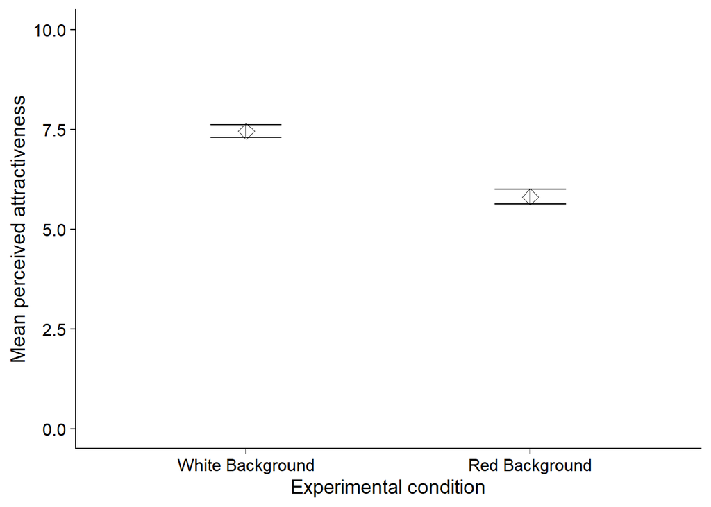

# Discussion

The main purpose of the study was to explore how the colour of a background, specifically the colours red and white, influence the attractiveness of the male in the photo shown to the female participants. The results of the study suggest that women are more attracted to pictures of men with a white background because the mean attractiveness score was 7.46 (2 d.p.) for the white background condition (or the control condition) and 5.81 (2 d.p.) for the red condition (or the experimental condition). This result contradicts the result of the original study by Elliot et al. (2010) where the women rated the man in the photo with the red background as more attractive. Our study conducted was identical to Elliot et al. (2010).

There are many reasons for the discrepancies in the results which include possible criticisms with the study like a small sample size (which was made smaller due to the removal of several people who were either too young, too old, or entered in an invalid age). Whilst the study by Prokop et al. (2015) had different results to our study, an understanding can be found on how a large sample size of 249 participants may make results more reliable. This is because a large sample size can accommodate for other conflicting variables such as the extent that the women are attracted to men judging by their own looks (Wen et al., 2014).

Other reasons for the discrepancies can be illustrated through the results of other studies. For example, Hesslinger et al. (2015) repeated the study by Elliot et al. (2010) and found no correlation between the colour of the photo and the perceived attractiveness of the men which implies that perhaps there was never any link between a red background and attraction in the first place. Some other studies to see if there are any underlying issues that cause people to be attracted to the colour red such as Prokop et al. (2015) where the fertility of the women were examined to see if that effects how the colour red influences them to be more attracted to the man in the photo. In that study it was determined that the ovulatory status of the women did effect how attracted they were to the man in the red background. This is supported by Beall & Tracy, (2013) where it was found that women are more likely to wear red or pink when they are at a high conception risk. Perhaps, in our study the participants were not fertile enough to have been influenced by the colour red. This would explain why the red background mean is lower than the white background mean. This is also something which could not have been controlled and may have played a large role in the discrepancies between our study and the original by Elliot et al. (2010).

In addition, there are other factors that could have affected how women react to the colour of the background. For example in Penna et al. (2015)’s study it was found that the hair style and lips of the man affected how the women were attracted to the coloured backgrounds because certain looks are perceived better in different colours. Also, Re et al. (2011)’s study found that women are more attracted to men that have more red on their skin because it symbolises health so the man used in the study may not have had a significant red colouration on their faces to influence women to be more attracted to the red background. The facial expressions are also very important because a study by Buechner et al. (2015) found that red only influences the attractiveness of men when they are showing pride and decrease their attractiveness if they look sad.

In order to see what caused the discrepancies between our study and the original study Elliot et al. (2010), another study must be done to identify what caused the attenuation of the attractiveness to the man with the red background. This experiment would include the same man in either a red or white background, also with the photo being greyscale so there is no chance of red tones on the skin affecting how the attraction from the women. The study would also document where the women are in the ovulation cycle and have them take the experiment when they are high and low in the cycle in order to see how much it affects the attractiveness of the men.

# References

Beall, A. T., & Tracy, J. L. (2013). Women Are More Likely to Wear Red or Pink at Peak Fertility. Psychological Science, 24(9), 1837–1841. https://doi.org/10.1177/0956797613476045

Buechner, V. L., Maier, M. A., Lichtenfeld, S., & Elliot, A. J. (2015). Emotion Expression and Color: Their Joint Influence on Perceived Attractiveness and Social Position. Current Psychology, 34(2), 422–433. https://doi.org/10.1007/s12144-014-9266-x

Elliot, A. J., Kayser, D. N., Greitemeyer, T., Lichtenfeld, S., Gramzow, R. H., Maier, M. A., & Liu, H. (2010). Red, rank, and romance in women viewing men. Journal of Experimental Psychology. General, 139(3), 399–417. https://doi.org/10.1037/a0019689

Hesslinger, V. M., Goldbach, L., & Carbon, C.-C. (2015). Men in red: A reexamination of the red-attractiveness effect. Psychonomic Bulletin & Review, 22(4), 1142–1148. https://doi.org/10.3758/s13423-015-0866-8

Penna, V., Fricke, A., Iblher, N., Eisenhardt, S. U., & Stark, G. B. (2015). The attractive lip: A photomorphometric analysis. Journal of Plastic, Reconstructive & Aesthetic Surgery, 68(7), 920–929. https://doi.org/10.1016/j.bjps.2015.03.013

Prokop, P., Pazda, A. D., & Elliot, A. J. (2015). Influence of conception risk and sociosexuality on female attraction to male red. Personality and Individual Differences, 87, 166–170. https://doi.org/10.1016/j.paid.2015.07.042

Re, D. E., Whitehead, R. D., Xiao, D., & Perrett, D. I. (2011). Oxygenated-Blood Colour Change Thresholds for Perceived Facial Redness, Health, and Attractiveness. PLOS ONE, 6(3), e17859. https://doi.org/10.1371/journal.pone.0017859

Wen, F., Zuo, B., Wu, Y., Sun, S., & Liu, K. (2014). Red is Romantic, but Only for Feminine Females: Sexual Dimorphism Moderates Red Effect on Sexual Attraction. Evolutionary Psychology, 12(4), 147470491401200. https://doi.org/10.1177/147470491401200404